# Damage Analysis

# Data

A GAM of Furrycat’s data shows a strong relationship between damage and power.

Note that damage spread was changed near patch 14.1, so many of the examples in the Furrycat data set are not valid.

- https://archive.cuemu.com/thread/28261
- https://archive.cuemu.com/thread/28182
- https://archive.cuemu.com/thread/28257
- https://archive.cuemu.com/thread/28312

We can see this immediately from the complete data set as well.

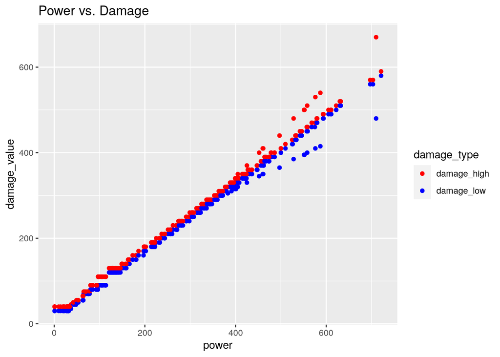

Where we see a rather striking segment starting at around $damage_{min} \approx 300$.

For the purposes of fitting the data, we will remove these pre-patch examples.

```r
post_patch_dataset <- normalized_df %>%
  filter((damage_spread > 10 & power >= 380) | power < 380)
```

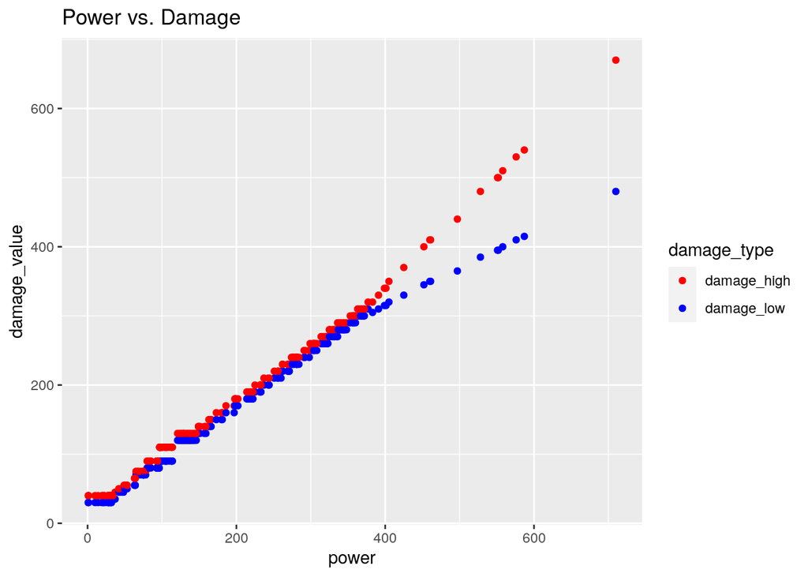

A naive general additive model shows high influence from power.

```r
model_low <- gam(
  formula = damage_low ~
    s(hardiness) +
    s(fortitude) +
    s(dexterity) +
    s(endurance) +
    s(intellect) +
    s(cleverness) +
    s(courage) +
    s(dependability) +
    s(power) +
    s(fierceness) +
    armor,
  family = gaussian(),
  data = post_patch_dataset
)
```

```
##
## Family: gaussian
## Link function: identity
##
## Formula:
## damage_low ~ s(hardiness) + s(fortitude) + s(dexterity) + s(endurance) +
##     s(intellect) + s(cleverness) + s(courage) + s(dependability) +
##     s(power) + s(fierceness) + armor
##
## Parametric coefficients:
##             Estimate Std. Error t value Pr(>|t|)
## (Intercept) 157.3054     0.2924 537.947   <2e-16 ***
## armor        -1.2650     1.0974  -1.153     0.25
## ---
## Signif. codes:  0 '***' 0.001 '**' 0.01 '*' 0.05 '.' 0.1 ' ' 1
##
## Approximate significance of smooth terms:
##                    edf Ref.df        F p-value
## s(hardiness)     1.689  2.128    2.705  0.0746 .
## s(fortitude)     1.000  1.000    0.757  0.3851
## s(dexterity)     2.987  3.740    3.203  0.0143 *
## s(endurance)     1.000  1.000    0.118  0.7310
## s(intellect)     1.000  1.000    3.606  0.0587 .
## s(cleverness)    1.000  1.000    0.063  0.8016
## s(courage)       1.000  1.000    0.298  0.5853
## s(dependability) 2.318  2.957    1.660  0.2142
## s(power)         8.592  8.945 4456.709  <2e-16 ***
## s(fierceness)    1.000  1.000    0.087  0.7682
## ---
## Signif. codes:  0 '***' 0.001 '**' 0.01 '*' 0.05 '.' 0.1 ' ' 1
##
## R-sq.(adj) =  0.998   Deviance explained = 99.8%
## GCV = 19.673  Scale est. = 18.051    n = 286
```

And $damage_{high}$ is best expressed in terms of $damage_{low}$.

```r
model_high <- gam(
  formula = damage_high ~ s(damage_low),
  family = gaussian(),
  data = post_patch_dataset
)
summary(model_high)
```

```
##
## Family: gaussian
## Link function: identity
##
## Formula:
## damage_high ~ s(damage_low)
##
## Parametric coefficients:
##             Estimate Std. Error t value Pr(>|t|)
## (Intercept)  171.346      0.196   874.3   <2e-16 ***
## ---
## Signif. codes:  0 '***' 0.001 '**' 0.01 '*' 0.05 '.' 0.1 ' ' 1
##
## Approximate significance of smooth terms:
##                 edf Ref.df     F p-value
## s(damage_low) 8.805  8.985 33106  <2e-16 ***
## ---
## Signif. codes:  0 '***' 0.001 '**' 0.01 '*' 0.05 '.' 0.1 ' ' 1
##
## R-sq.(adj) =  0.999   Deviance explained = 99.9%
## GCV = 11.374  Scale est. = 10.984    n = 286
```

A simple change-point detection and segmentation analysis gives the piecewise-defined regressions.

```r
model <- lm(damage_low ~ power, data = post_patch_dataset)
summary(model)
```

```
##
## Call:
## lm(formula = damage_low ~ power, data = post_patch_dataset)
##
## Residuals:
##     Min      1Q  Median      3Q     Max
## -63.546  -5.810   1.459   6.495  13.262
##
## Coefficients:
##              Estimate Std. Error t value Pr(>|t|)
## (Intercept) 18.088064   0.941345   19.21   <2e-16 ***
## power        0.740082   0.004125  179.40   <2e-16 ***
## ---
## Signif. codes:  0 '***' 0.001 '**' 0.01 '*' 0.05 '.' 0.1 ' ' 1
##
## Residual standard error: 9.035 on 284 degrees of freedom
## Multiple R-squared:  0.9913, Adjusted R-squared:  0.9912
## F-statistic: 3.219e+04 on 1 and 284 DF,  p-value: < 2.2e-16
```

```
##
##  ***Regression Model with Segmented Relationship(s)***
##
## Call:
## segmented.lm(obj = model, seg.Z = ~power, psi = 380)
##
## Estimated Break-Point(s):
##                Est. St.Err
## psi1.power 367.009   6.33
##
## Meaningful coefficients of the linear terms:
##              Estimate Std. Error t value Pr(>|t|)
## (Intercept) 12.343985   0.591159   20.88   <2e-16 ***
## power        0.780646   0.003071  254.22   <2e-16 ***
## U1.power    -0.252538   0.011690  -21.60       NA
## ---
## Signif. codes:  0 '***' 0.001 '**' 0.01 '*' 0.05 '.' 0.1 ' ' 1
##
## Residual standard error: 5.063 on 282 degrees of freedom
## Multiple R-Squared: 0.9973,  Adjusted R-squared: 0.9972
##
## Boot restarting based on 6 samples. Last fit:
## Convergence attained in 3 iterations (rel. change 7.5492e-16)
```

```
## $power
##               Est.
## intercept1  12.344
## intercept2 105.030
```

```
## $power
##           Est.   St.Err. t value CI(95%).l CI(95%).u
## slope1 0.78065 0.0030708 254.210   0.77460   0.78669
## slope2 0.52811 0.0112790  46.822   0.50591   0.55031
```

Which visually fits.

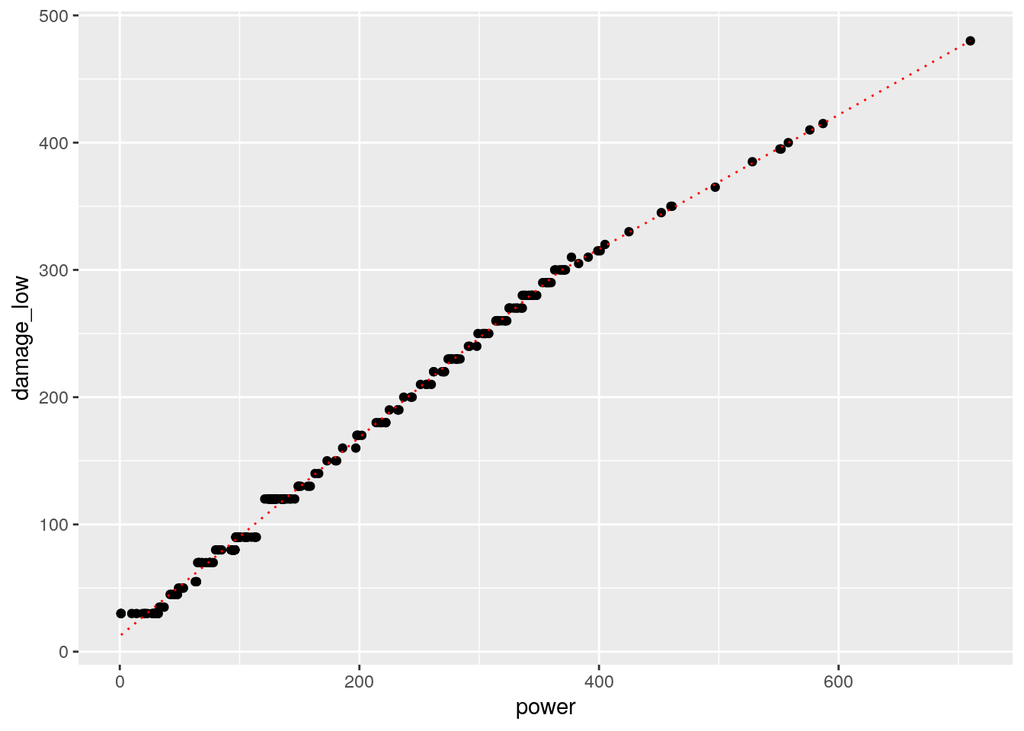

What about $damage_{high}$? That’s even more simple, especially if expressed in terms of $damage_{low}$.

```r
model <- lm(damage_high ~ damage_low, data = post_patch_dataset)
segmented.model <- segmented(model, seg.Z = ~damage_low, psi=300)
summary(segmented.model)
```

```
##
##  ***Regression Model with Segmented Relationship(s)***
##
## Call:
## segmented.lm(obj = model, seg.Z = ~damage_low, psi = 300)
##
## Estimated Break-Point(s):
##                     Est. St.Err
## psi1.damage_low 301.612  1.363
##
## Meaningful coefficients of the linear terms:
##                Estimate Std. Error t value Pr(>|t|)
## (Intercept)   10.585290   0.422076   25.08   <2e-16 ***
## damage_low     0.999041   0.002552  391.43   <2e-16 ***
## U1.damage_low  1.013791   0.017460   58.06       NA
## ---
## Signif. codes:  0 '***' 0.001 '**' 0.01 '*' 0.05 '.' 0.1 ' ' 1
##
## Residual standard error: 3.438 on 282 degrees of freedom
## Multiple R-Squared: 0.999,  Adjusted R-squared: 0.999
##
## Boot restarting based on 6 samples. Last fit:
## Convergence attained in 6 iterations (rel. change 4.0206e-12)
```

```r
intercept(segmented.model)
```

```
## $damage_low
##                Est.
## intercept1   10.585
## intercept2 -295.190
```

```r
slope(segmented.model)
```

```
## $damage_low
##           Est.   St.Err. t value CI(95%).l CI(95%).u
## slope1 0.99904 0.0025523  391.43   0.99402    1.0041
## slope2 2.01280 0.0172720  116.54   1.97880    2.0468
```

Which also fits.

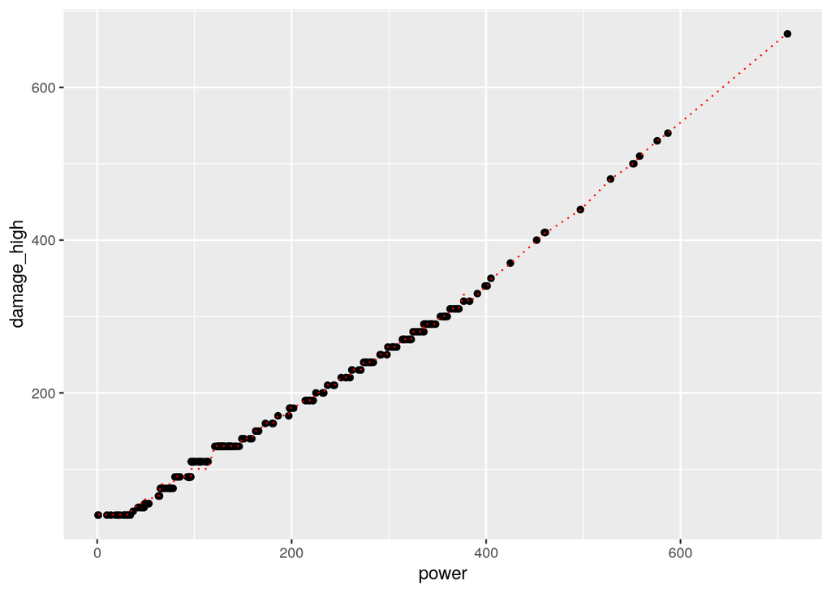

# Conclusion

Damage is roughly captured by the following formulas,

$$\begin{equation}
damage_{high} \approx
\left\{\begin{array}{lr}
10 + damage_{low}, & damage_{low} \le 300 \\
2 * damage_{low} - 290, & damage_{low} > 300
\end{array}\right.
\end{equation}$$

Furthermore, $damage_{high}$ will round to the nearest $10$, and $damage_{low}$ will (sometimes) round to the nearest $5$. There is more investigation needed into the rounding of these values; my belief is that $damage_{high}$ is based on the *non-rounded* value of $damage_{low}$, and then the rounding occurs differently. More investigation on that behavior is needed, however I do consider some of that data of suspect quality, especially where the difference between $damage_{high}$ and $damage_{low}$ is allegedly $5$.